# Analysis of Titanic dataset

This program reads data on survival of passengers on the Titanic. Find more information in the [data dictionary](https://github.com/pmean/data/blob/main/files/titanic.yaml).

This code was written by Steve Simon on 2024-11-09 and is placed in the public domain.

## Load the tidyverse library

```r
library(broom)
library(epitools)
library(tidyverse)
```

#### Comments on the code

For most of your programs, you should load the [tidyverse library](https://www.tidyverse.org/). The messages and warnings are suppressed.

In previous programs, I put a label for each chunk inside the curly braces ({}). It is recommended instead to put the label on a separate line inside the program chunk. It is a bit more work to provide a unique label for each chunk, but it helps quite a bit to isolate where to look when your code produces an error.

## Read the data and view a brief summary

```r
ti <- read_tsv(
  file="../data/titanic.txt",
  col_names=TRUE,
  col_types="ccncn",
  na="NA")
names(ti) <- tolower(names(ti))
glimpse(ti)
```

```
Rows: 1,313
Columns: 5
$ name     <chr> "Allen, Miss Elisabeth Walton", "Allison, Miss Helen Loraine"…
$ pclass   <chr> "1st", "1st", "1st", "1st", "1st", "1st", "1st", "1st", "1st"…
$ age      <dbl> 29.00, 2.00, 30.00, 25.00, 0.92, 47.00, 63.00, 39.00, 58.00, …
$ sex      <chr> "female", "female", "male", "female", "male", "male", "female…
$ survived <dbl> 1, 0, 0, 0, 1, 1, 1, 0, 1, 0, 0, 1, 1, 1, 0, 1, 0, 0, 1, 1, 1…
```

#### Comments on the code

Use read_tsv from the [readr package](https://readr.tidyverse.org/) to read this file. Use col_names=TRUE because the column names are included as the first row of the file. The col_types=“ccncn” specifies the first second and fourth columns as strings and the third and fifth as numeric. There are missing values in this dataset, designated by the letters “NA”.

## Replace numeric codes for survived

```r
ti$survived <-
    factor(
        ti$survived,
        level=1:0,
        labels=c("yes", "no"))
```

#### Comments on the code

The [factor function](https://stat.ethz.ch/R-manual/R-devel/library/base/html/factor.html) places the levels of a categorical variable in a specific order and (optionally) attaches labels to each level. In this code, the number codes are reordered so that 1 appears first followed by 0. The labels “yes” and “no” are attached to these two codes.

## Get counts of sex by survival

```r
table1 <-xtabs(~sex+survived, data=ti)
table1
```

```
        survived
sex      yes  no
  female 308 154
  male   142 709
```

#### Comments on the code

The [table function](https://stat.ethz.ch/R-manual/R-devel/library/base/html/table.html) or the [xtabs function](https://stat.ethz.ch/R-manual/R-devel/library/stats/html/xtabs.html) creates a matrix with the number of observations in each combination of sex and survived. The [count function](https://dplyr.tidyverse.org/reference/count.html) provides an alternative where these values are placed in a single column.

#### Interpretation of the output

There are 154 female passengers who died and 308 who survived. There are 709 male passengers who died and 142 who survived.

## Get proportions for died/survived by sex

```r
table1 |>
  proportions("sex")
```

```
        survived
sex            yes        no
  female 0.6666667 0.3333333
  male   0.1668625 0.8331375
```

#### Comments on the code

The [proportions function](https://stat.ethz.ch/R-manual/R-devel/library/base/html/proportions.html) calculate proportions for a matrix, either by row (margin=1), by column (margin=2) or across all cells (margin=NULL). This code shows an alternative where you specify which variable to summarize across. The line proportions(“sex”) tells R to compute totals for each level of sex and divide by those totals. In this case, since sex represents the rows of table1, R produces row percentages. This syntax is easier to remember than margin=1 and margin=2.

#### Interpretation of the output

The proportion of women who died is 33%. The proportion of men who died is much higher at 83%.

## Bar chart

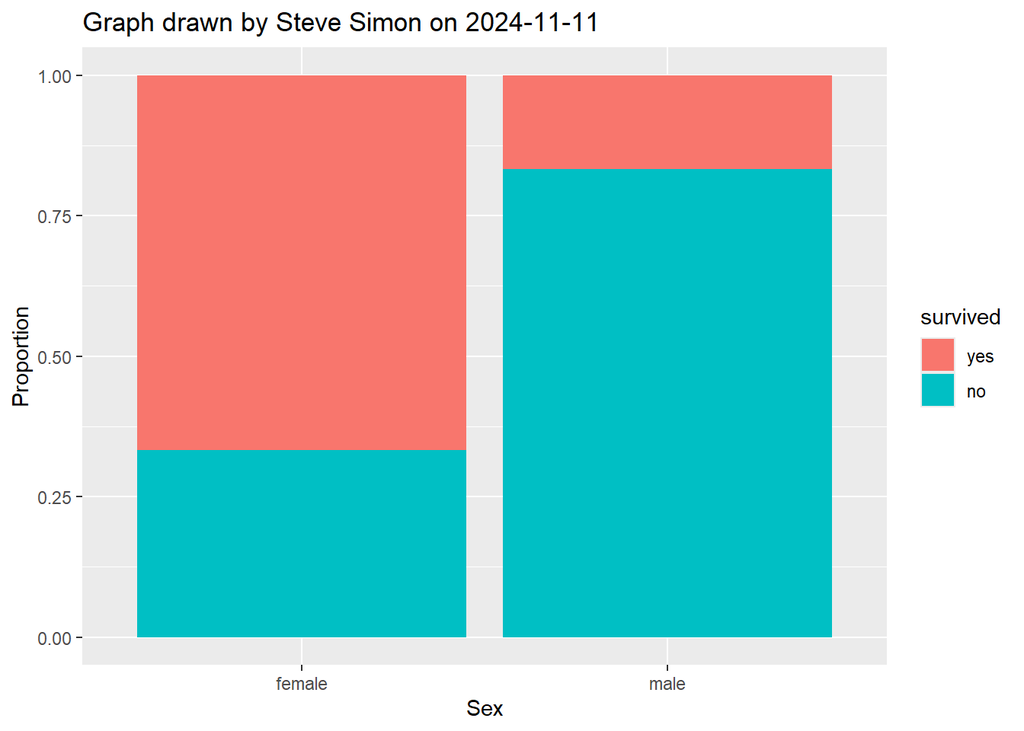

```r
ti |>
  ggplot() +
    aes(x = sex, fill = survived) +
    geom_bar(position = "fill") +
      xlab("Sex") +
      ylab("Proportion") +
      ggtitle("Graph drawn by Steve Simon on 2024-11-11")
```

#### Interpretation of the output

I am not a big fan of bar charts, but they are quite popular. This bar chart shows a large disparity in the proportion who survived in each sex (the upper portion of the bar in peach). Equivalently, you can say that there is a large disparity in the proportion who died in each sex (the lower portion of the bar in green-blue).

## Hypothesis test for two proportions

```r
prop.test(table1, correct=FALSE)
```

```
    2-sample test for equality of proportions without continuity correction

data:  table1
X-squared = 332.06, df = 1, p-value < 2.2e-16
alternative hypothesis: two.sided
95 percent confidence interval:
 0.4500519 0.5495564
sample estimates:
   prop 1    prop 2
0.6666667 0.1668625
```

#### Comments on the code

The [prop.test function](https://search.r-project.org/R/refmans/stats/html/prop.test.html) does not work on raw data. You need to get summary counts, either from the table function or the xtabs function. The option correct=FALSE informs R to not use the [Yates continuity correction](https://www.statskingdom.com/121proportion_normal2.html).

## Power calculation

```r
power.prop.test(p1=0.17, p2=0.67, power=0.9)
```

```
     Two-sample comparison of proportions power calculation

              n = 18.30686
             p1 = 0.17
             p2 = 0.67
      sig.level = 0.05
          power = 0.9
    alternative = two.sided

NOTE: n is number in *each* group
```

```r
power.prop.test(
p1=0.10,
p2=0.20,
power=0.9,
sig.level=0.05)
```

```
     Two-sample comparison of proportions power calculation

              n = 265.856
             p1 = 0.1
             p2 = 0.2
      sig.level = 0.05
          power = 0.9
    alternative = two.sided

NOTE: n is number in *each* group
```

#### Comments on the code

The [power.prop.test](https://stat.ethz.ch/R-manual/R-devel/library/stats/html/power.prop.test.html) function will compute a sample size if you specify the two group probabilities, the significance level, and the power. It will also do other calculations, such as the minimum difference in probabilities that you could detect for a specific sample size and a specific power.

#### Interpretation of the output

Clearly, a sample size of 1,313 passengers provided more than enough power and precision, especially considering that the difference in survival rates was so large. Out of curiosity, what sample size would still be adequate for testing a shift of 50% from a survival rate of 17% to a survival rate of 67%? If you wanted power to be at least 90%, then a sample size of only 19 passengers of each sex would be needed.

## Chi-squared test

```r
chisq.test(table1, correct=FALSE)
```

```
    Pearson's Chi-squared test

data:  table1
X-squared = 332.06, df = 1, p-value < 2.2e-16
```

#### Comments on the code

The [chisq.test function](https://stat.ethz.ch/R-manual/R-devel/library/stats/html/chisq.test.html) calculates a chi-square test of independence. It takes input in a variety of forms. In this example, it uses a crosstabulation computed by the xtabs command as input.

This function also will run a goodness-of-fit test, which is not discussed in this lecture.

#### Interpretation of the output

The chi-squared statistic is much larger than the degrees of freedom and the p-value is small. You should reject the null hypothesis and conclude that sex and survival are related (not independent)

## Fisher’s Exact test

```r
fisher.test(table1)
```

```
    Fisher's Exact Test for Count Data

data:  table1
p-value < 2.2e-16
alternative hypothesis: true odds ratio is not equal to 1
95 percent confidence interval:
  7.601263 13.122462
sample estimates:
odds ratio
  9.965185
```

#### Comments on the code

The [fisher.test function](https://stat.ethz.ch/R-manual/R-devel/library/stats/html/fisher.test.html) calculates the Fisher’s exact test, which is helpful for small sample sizes. The 1,313 passengers on the Titanic do not constitute a small sample size by any means. This test is just shown as an example of how to calculate this test.

#### Interpretation of the output

The p-value is small. You should reject the null hypothesis and conclude that sex and survival are related (not independent). The estimated odds ratio is 9.97. The confidence interval for the odds ratio excludes the value of 1 leading to the same conclusion. In fact, even after allowing for sampling error that odds of survival are at least 7.6 times greater for women than for me.

## Odds ratio calculation

```r
oddsratio(table1)
```

```
$data
        survived
sex      yes  no Total
  female 308 154   462
  male   142 709   851
  Total  450 863  1313

$measure
        odds ratio with 95% C.I.
sex      estimate    lower    upper
  female 1.000000       NA       NA
  male   9.956188 7.662525 13.00928

$p.value
        two-sided
sex      midp.exact fisher.exact   chi.square
  female         NA           NA           NA
  male            0 4.826448e-74 3.425855e-74

$correction
[1] FALSE

attr(,"method")
[1] "median-unbiased estimate & mid-p exact CI"
```

#### Comments on the code

The oddsratio function and riskratio function (see below) are part of the [epitools library](https://cran.r-project.org/web/packages/epitools/epitools.pdf). It produces an odds ratio and confidence interval and p-values associated with the Fisher’s Exact test and the Chi-squared test of independence.

#### Interpretation of the output

We are 95% confident that the odds ratio of survival for women versus men is at least 7.7 and possibly as large as 13, after accounting for sampling error. This interval excludes the value of 1, so you can conclude that the risk of death is much higher for men than for women. Equivalently you could conclude that the odds of survival are much higher for women than for men.

## Risk ratio calculation, 1

```r
table1 |>
  proportions("sex")
```

```
        survived
sex            yes        no
  female 0.6666667 0.3333333
  male   0.1668625 0.8331375
```

#### Interpretation of the output

Before calculating the risk ratio, let’s look at the row percentages one more time. The probability of survival is around 2/3 for women and about 1/6 for men. This means that the risk ratio from a survival perspective is around 4 (2/3 divided by 1/6). The probability of death is 1/3 for females and about 5/6 for males. The risk ratio from a mortality perspective is 0.4 (1/3 divided by 5/6)

## Risk ratio calculation, 2

```r
riskratio(table1)
```

```
$data
        survived
sex      yes  no Total
  female 308 154   462
  male   142 709   851
  Total  450 863  1313

$measure
        risk ratio with 95% C.I.
sex      estimate    lower    upper
  female 1.000000       NA       NA
  male   2.499412 2.189428 2.853285

$p.value
        two-sided
sex      midp.exact fisher.exact   chi.square
  female         NA           NA           NA
  male            0 4.826448e-74 3.425855e-74

$correction
[1] FALSE

attr(,"method")
[1] "Unconditional MLE & normal approximation (Wald) CI"
```

#### Interpretation of the output

The risk ratio is comparing the probability of death between men and women. Men have 2.5 times higher probability of death compared to women. The confidence interval excludes the value of 1, indicating a statistically significant increase.

## Risk ratio calculation, 3

```r
riskratio(table1, rev="columns")
```

```
$data
        survived
sex       no yes Total
  female 154 308   462
  male   709 142   851
  Total  863 450  1313

$measure
        risk ratio with 95% C.I.
sex       estimate     lower     upper
  female 1.0000000        NA        NA
  male   0.2502938 0.2125647 0.2947195

$p.value
        two-sided
sex      midp.exact fisher.exact   chi.square
  female         NA           NA           NA
  male            0 4.826448e-74 3.425855e-74

$correction
[1] FALSE

attr(,"method")
[1] "Unconditional MLE & normal approximation (Wald) CI"
```

#### Interpretation of the output

The risk ratio is comparing the probability of survival between men and women. Men has one-fourth the probability of survival compared to women. The confidence interval excludes the value of 1, indicating that men have a statistically significantly lower probability of survival compared to women.

## Save data for later use

```r
save(ti, file="../data/titanic.RData")
```

#### Comments on the code

It is usually a good idea to [save](https://stat.ethz.ch/R-manual/R-devel/library/base/html/save.html) your data in an RData file to make it easier to retrieve this data later (with the [load function](https://stat.ethz.ch/R-manual/R-devel/library/base/html/save.html)).